# Analyse des Parcs Nationaux aux Etats-Unis

Guillaume Faynot

28/10/2020

**Présentation du jeu de données :**

Les données datent de 2019 : elles décrivent l’affluence des parks nationaux des diiférents états américains. Nous avons 4 jeux de données : le prix de l’essence, la géolocalisation, les visites des parks et la population des états. Dans le jeu de données park_visits, nous avons un total d’environ 22 000 données.

On peut retrouver la base de données ici : [lien de la base de données](https://github.com/rfordatascience/tidytuesday/tree/master/data/2019/2019-09-17)

**Importation des jeu de données :**

Import du jeu de données park_visits

- year_raw *(Year of record)*
- gnis_id *(ID for shapefile and long-lat lookup)*
- geometry *(Geometric shape for shapefile)*
- metadata *(URL to metadata about the park)*
- number_of_records *(Number of records)*
- parkname *(Full park name)*
- region *(US Region where park is located)*
- state *(State abbreviation)*
- unit_code *(Park code abbreviation)*
- unit_name *(Park Unit name)*
- unit_type *(Park unit type)*
- visitors *(Number of visitors)*

Il faut savoir que je vais supprimer certaines lignes car elles sont notées comme “Total” dans la variable “Year”. Cela pourrait perturber notre analyse.

```r
park_visits <- readr::read_csv("https://raw.githubusercontent.com/rfordatascience/tidytuesday/master/data/2019/2019-09-17/national_parks.csv")
library(dplyr)
park_visits %>%
  filter(year != "Total") -> park_visits
head(park_visits)
```

```
## # A tibble: 6 x 12
##   year  gnis_id geometry metadata number_of_recor~ parkname region state
##   <chr> <chr>   <chr>    <chr>               <dbl> <chr>    <chr>  <chr>
## 1 1904  1163670 POLYGON  <NA>                    1 Crater ~ PW     OR
## 2 1941  1531834 MULTIPO~ <NA>                    1 Lake Ro~ PW     WA
## 3 1961  2055170 MULTIPO~ <NA>                    1 Lewis a~ PW     WA
## 4 1935  1530459 MULTIPO~ <NA>                    1 Olympic  PW     WA
## 5 1982  277263  POLYGON  <NA>                    1 Santa M~ PW     CA
## 6 1919  578853  MULTIPO~ <NA>                    1 <NA>     NE     ME
## # ... with 4 more variables: unit_code <chr>, unit_name <chr>, unit_type <chr>,
## #   visitors <dbl>
```

Import du jeu de données state_pop :

- year *(Jan 1st of year)*
- state *(State abbreviation)*
- pop *(Population)*

```r
state_pop <- readr::read_csv("https://raw.githubusercontent.com/rfordatascience/tidytuesday/master/data/2019/2019-09-17/state_pop.csv")
head(state_pop)
```

```
## # A tibble: 6 x 3
##    year state     pop
##   <dbl> <chr>   <dbl>
## 1  1900 AL    1830000
## 2  1901 AL    1907000
## 3  1902 AL    1935000
## 4  1903 AL    1957000
## 5  1904 AL    1978000
## 6  1905 AL    2012000
```

Import du jeu de données gas_price

- year *(Year (Jan 1st))*
- gas_current *(Gas price in that year (dollars/gallon))*
- gas_constant *(Gas price (constant 2015 dollars/gallon))*

```r
gas_price <- readr::read_csv("https://raw.githubusercontent.com/rfordatascience/tidytuesday/master/data/2019/2019-09-17/gas_price.csv")
head(gas_price)
```

```
## # A tibble: 6 x 3
##    year gas_current gas_constant
##   <dbl>       <dbl>        <dbl>
## 1  1929        0.21         2.38
## 2  1930        0.2          2.3
## 3  1931        0.17         2.18
## 4  1932        0.18         2.61
## 5  1933        0.18         2.66
## 6  1934        0.19         2.67
```

Import du jeu de données location

- lon *(longitude)*
- lat *(latitude)*
- gnis_id *(ID for shapefile and long-lat lookup)*

```r
location <- readr::read_csv("https://raw.githubusercontent.com/rfordatascience/tidytuesday/master/data/2019/2019-09-17/locations.csv")
head(location)
```

```
## # A tibble: 6 x 3
##      lon   lat gnis_id
##    <dbl> <dbl> <chr>
## 1  146.   15.2 1879026
## 2 -123.   48.2 1888910
## 3 -119.   47.9 1531834
## 4 -124.   47.8 1530459
## 5  -68.2  44.4 578853
## 6 -156.   19.1 2035608
```

```r
#Gas_current = Gas price in that year (dollars/gallon)
#Gas_constant = Gas price (constant 2015 dollars/gallon)
```

# **1) Représenter graphiquement l’évolution des prix en fonction des années : Les prix sont-ils linéairement croissants? exponentiellement croissant ?**

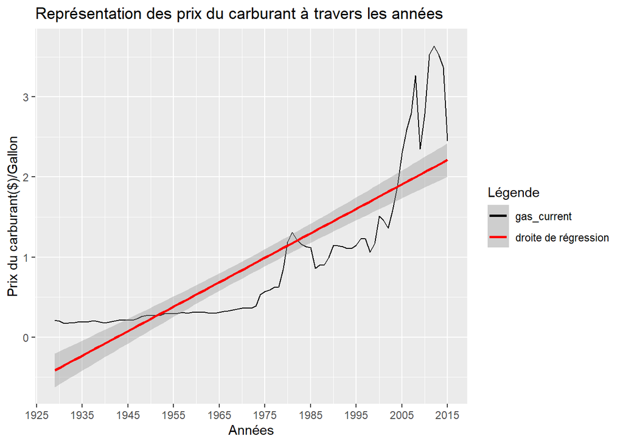

```r
library(ggplot2)
ggplot(data=gas_price, aes(x=year, y=gas_current, colour = "black"))+
  geom_line()+
  geom_smooth(method="lm", aes(color="red"))+
  scale_color_identity(name = "Légende",
                    breaks = c("black", "red"),
                    labels = c("gas_current", "droite de régression"),
                    guide = "legend")+
    labs(title="Représentation des prix du carburant à travers les années",x ="Années", y = "Prix du carburant($)/Gallon")+
  scale_x_continuous(breaks=seq(1925,2015,10))
```

*Commentaires :*

# **2) Montrer que la population augmente : Augmente-t-elle constamment?**

```r
state_pop %>%
  select(year,pop) %>%
  filter(!is.na(pop)) %>%
  group_by(year) %>%
  summarise(somme = sum(pop))-> PopAugmentation
```

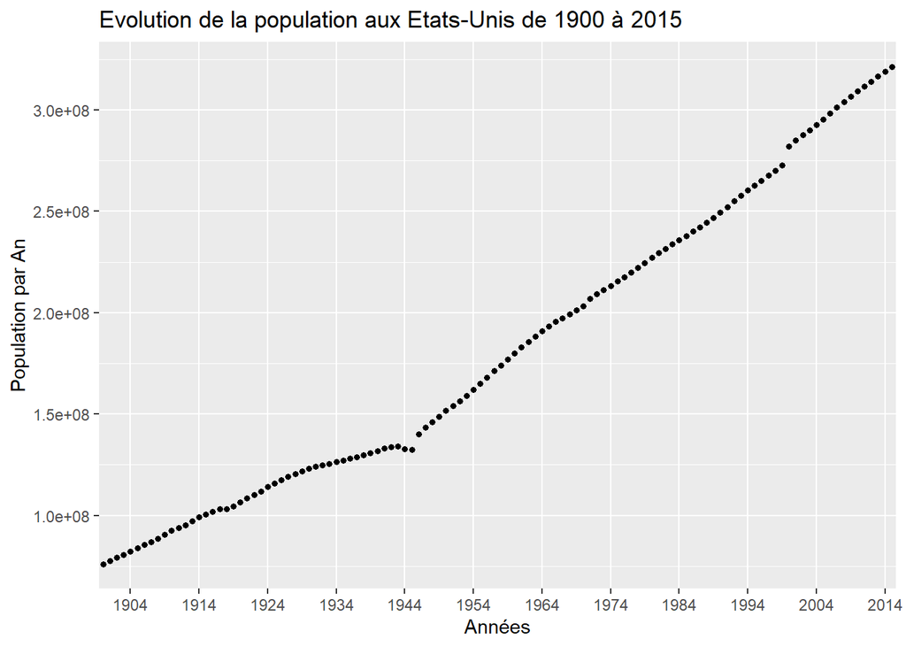

```r
ggplot(PopAugmentation, aes(x =as.factor(year), y = somme))+
  geom_point(shape=20, size=2)+
  scale_x_discrete(breaks=seq(1904,2016,10))+
  labs(title="Evolution de la population aux Etats-Unis de 1900 à 2015",x ="Années", y = "Population par An")
```

*Commentaires :*

On voulait savoir si la population avait augmenté depuis 1904 et si oui, l’augmentation est constante ou non. Grâce à ce graphique, on peut voir que l’augmentation est belle et bien présente. De plus, celle-ci est principalement constante d’années en années. Regardons maintenant les états les plus impactés par cette augmentation.

# **3) Quel est l’état qui a le plus grand accroissement de la population ?**

```r
state_pop %>%
  select(state,pop) %>%
  group_by(state) %>%
  summarise(diff = max(pop)-min(pop)) %>%
  filter(!is.na(diff)) -> PopAugmentationPerState
PopAugmentationPerState <- PopAugmentationPerState[order(-PopAugmentationPerState$diff),]
PopAugmentationPerState[1:5,]
```

```
## # A tibble: 5 x 2
##   state     diff
##   <chr>    <dbl>
## 1 CA    37654818
## 2 TX    24414114
## 3 FL    19741272
## 4 NY    12512791
## 5 NC     8145802
```

```r
tail(PopAugmentationPerState,1)
```

```
## # A tibble: 1 x 2
##   state   diff
##   <chr>  <dbl>
## 1 VT    312855
```

*Commentaires :*

La californie est l’état ayant vécu l’augmentation de la population la plus forte du pays devant le Texas et la Floride. Maintenant, je voudrais savoir si une augmentation de la population signifie une augmentation des personnes qui voyagent ?

# **3.1) Représenter graphiquement l’évolution 1904 et 2015 de la population aux états unis**

```r
library(usmap)
```

```r
library(ggplot2)

head(statepop)
```

```
## # A tibble: 6 x 4
##   fips  abbr  full       pop_2015
##   <chr> <chr> <chr>         <dbl>
## 1 01    AL    Alabama     4858979
## 2 02    AK    Alaska       738432
## 3 04    AZ    Arizona     6828065
## 4 05    AR    Arkansas    2978204
## 5 06    CA    California 39144818
## 6 08    CO    Colorado    5456574
```

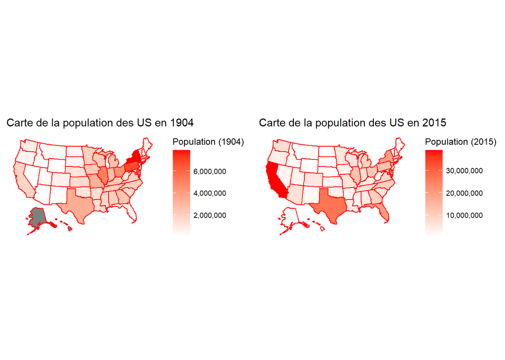

```r
state_pop %>%
  filter(year == "1904")->state_pop_1904

state_pop %>%
  filter(year == "2015")->state_pop_2015

library(cowplot)
plot_grid(plot_usmap(data = state_pop_1904, values = "pop", color = "red") +
  scale_fill_continuous(low = "white", high = "red",name = "Population (1904)", label = scales::comma) +
  theme(legend.position = "right")+
  labs(title = "Carte de la population des US en 1904"),

plot_usmap(data = state_pop_2015, values = "pop", color = "red") +
  scale_fill_continuous(low = "white", high = "red", name = "Population (2015)", label = scales::comma) +
  theme(legend.position = "right")+
  labs(title = "Carte de la population des US en 2015"))
```

*Commentaires :*

# **4) Est-ce que la population voyage plus dans le temps? (Comparer les nb de visites par années)**

```r
park_visits %>%
  select(year,visitors) %>%
  group_by(year) %>%
  summarise(somme = sum(visitors)) %>%
  filter(!is.na(year)) -> NbVisitsPerYear
```

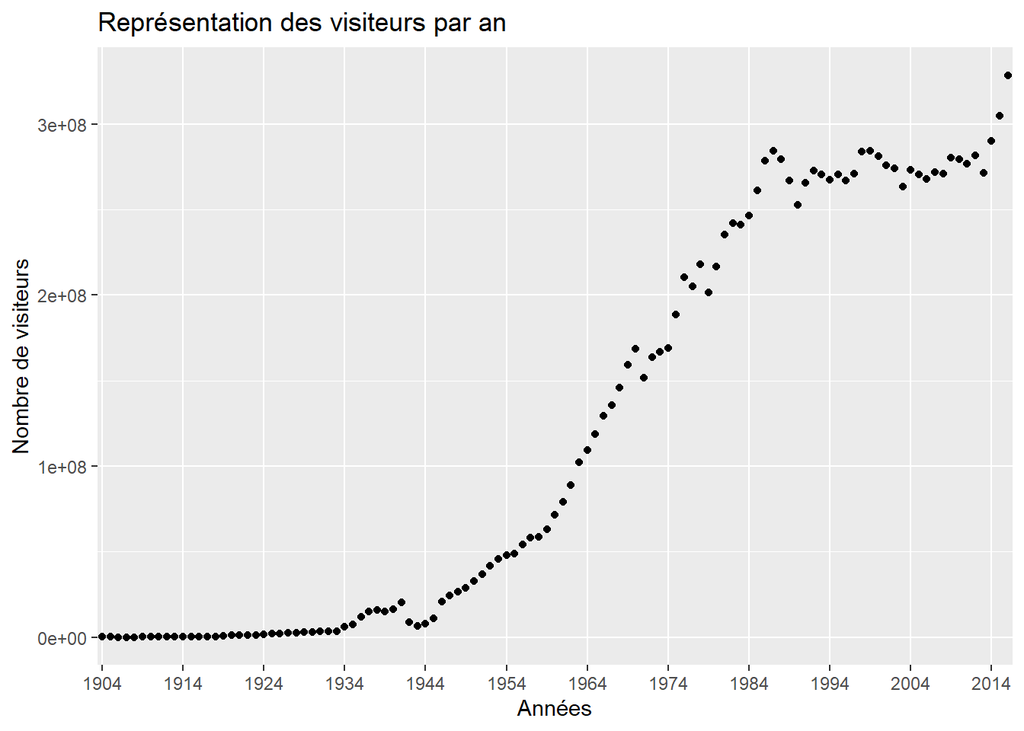

```r
NbVisitsPerYear$year <- as.character(NbVisitsPerYear$year )

ggplot(NbVisitsPerYear, aes(x = year, y = somme)) +
  scale_x_discrete(breaks=seq(1904,2016,10))+
  geom_point()+
  labs(title="Représentation des visiteurs par an",x ="Années", y = "Nombre de visiteurs")
```

*Commentaires :*

# **5) Est-ce que le prix de l’essence influe sur les visites des parcs? Plus il est bas, plus les visites augmentent?**

```r
Q1 <- merge(gas_price, park_visits, by.x = "year", by.y = "year")
Q1 %>%
  select(year,visitors) %>%
  group_by(year) %>%
  summarise(somme = sum(visitors)) %>%
  filter(!is.na(diff)) -> PrixGasVsVisitors
Q1[!duplicated(Q1$year),] %>%
  select(year,gas_current) -> test

PrixGasVsVisitors <- merge(PrixGasVsVisitors, test, by.x = "year", by.y = "year")

cor(PrixGasVsVisitors$somme,PrixGasVsVisitors$gas_current)
```

```
## [1] 0.7477048
```

*Commentaires :*

Cette étude sur le prix du carburant et le nombre de visite montre que les deux variables sont positivements corrélées. C’est à dire que le prix du carburant n’influe pas les déplacements des touristes.

# **6) Quel est l’état comportant le plus de parc?**

```r
park_visits_SansDoublons <- park_visits[!duplicated(park_visits$unit_name),]
park_visits_SansDoublons %>%
  select(state, unit_name) %>%
  group_by(state) %>%
  summarise(NombreDeParcs = n())-> NbParcParState
```

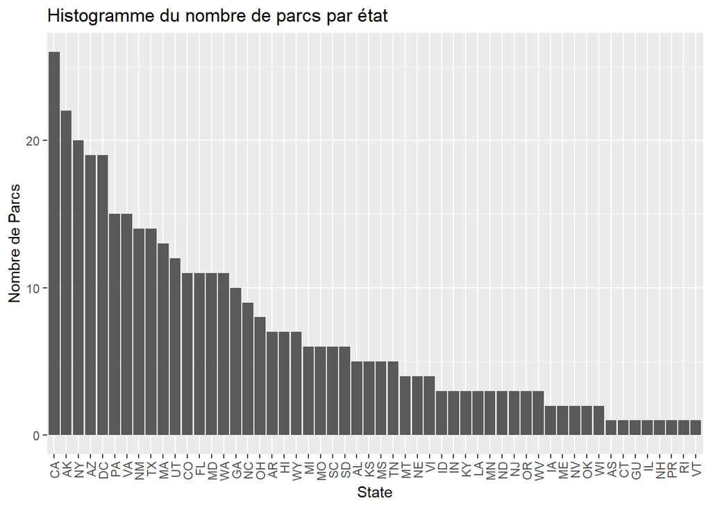

```r
NbParcParState <- NbParcParState[order(-NbParcParState$NombreDeParcs),]
NbParcParState$NombreDeParcs <- as.numeric(NbParcParState$NombreDeParcs)
ggplot(data=NbParcParState, aes(x=reorder(state, -NombreDeParcs), y=NombreDeParcs)) +
  geom_bar(stat="identity")+
  theme(axis.text.x = element_text(angle = 90, vjust = 0.5, hjust=1))+
  labs(title="Histogramme du nombre de parcs par état",
        x ="State", y = "Nombre de Parcs")
```

*Commentaires :*

L’état comportant le plus de parcs est la cafornie avec 26 parcs.

# **7) En 2015, Quel est l’état qui a réçu le plus de visiteurs?**

```r
park_visits %>%
  filter(year == "2015") %>%
  select(state,visitors) %>%
  group_by(state) %>%
  summarise(SommeVisitors = sum(visitors)) -> MostVisitors
MostVisitors <- MostVisitors[order(-MostVisitors$SommeVisitors),]
MostVisitors[1,]
```

```
## # A tibble: 1 x 2
##   state SommeVisitors
##   <chr>         <dbl>
## 1 DC         42006008
```

*Commentaires :*

L’état le plus visité, avec plus de 42 millions de visiteurs est le District of Columbia.

# **8) En 2015, Quel est le parc qui a réçu le plus de visiteurs?**

```r
park_visits %>%
  filter(year == "2015") %>%
  select(unit_name,visitors) %>%
  group_by(unit_name) %>%
  summarise(SommeVisitors = sum(visitors)) -> MostVisitorsPerPark
MostVisitorsPerPark <- MostVisitorsPerPark[order(-MostVisitorsPerPark$SommeVisitors),]
MostVisitorsPerPark[1,]
```

```
## # A tibble: 1 x 2
##   unit_name          SommeVisitors
##   <chr>                      <dbl>
## 1 Blue Ridge Parkway      15054603
```

*Commentaires :*

Le parcs le plus fréquenté en 2015 est le Blue ridge Parkway. Il y a eu 15 millions de visiteurs en 2015. La Blue Ridge Parkway est une route de catégorie National Scenic Byway aux États-Unis, connue pour ses paysages pittoresques. Elle traverse les États de Virginie et de Caroline du Nord. Sur ses 755 km, elle traverse les Blue Ridge Mountains.

# **9) Est-ce que la population voyage plus dans les états peuplés ou non peuplés?**

```r
state_pop %>%
  filter(year == "2015") %>%
  select(state,pop) %>%
  group_by(state) -> PopPerState

resultat <- merge(MostVisitors, PopPerState, by.x = "state", by.y = "state")
cor(resultat$SommeVisitors,resultat$pop)
```

```
## [1] 0.4686949
```

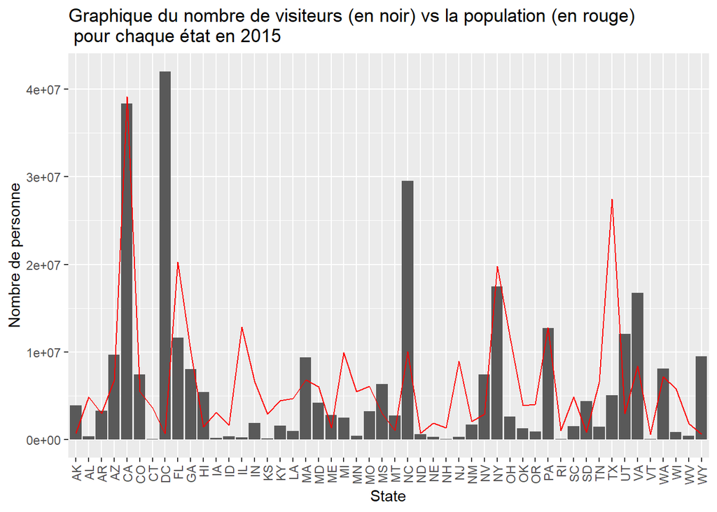

```r
ggplot(data=resultat, aes(x=state, y=SommeVisitors)) +
  geom_bar(stat="identity", position=position_dodge()) +
  geom_line(aes(y = pop), group = 1, color = 'red')+
  scale_color_identity(name = "Légende",
                    breaks = c("black","red"),
                    labels = c("Nombre de visiteurs", "Population de l'état"),
                    guide = "legend")+
  theme(axis.text.x = element_text(angle = 90, vjust = 0.5, hjust=1))+
  labs(title="Graphique du nombre de visiteurs (en noir) vs la population (en rouge)\n pour chaque état en 2015",
        x ="State", y = "Nombre de personne")
```

*Commentaires :*

Pour conclure cette étude, on ne peut affirmer ni l’un ni l’autre. Le coefficient de corrélation (0.46) n’est pas assez fort pour dire que les personnes préfèrent les états peuplés. Cependant, le graphique nous montre que certains états comme la CA sont peuplés et recoivent beaucoup de visiteurs. A contrario, le DC a une population très faible par rapport aux nombres de visiteurs!!

# **10) Quels sont les parc les plus visités?**

```r
library(tidyverse)
df <- merge(location, park_visits, by.x = "gnis_id", by.y = "gnis_id")
df <- df[!duplicated(df$gnis_id),]
newdf <- df %>% select(lon, lat, state, visitors, unit_name)
attach(newdf)
newdf <- newdf[order(-visitors),]
newdf <- newdf[1:10,]
newdf
```

```
##              lon      lat state visitors
## 13525  -76.83522 39.06320    DC  8934149
## 20493  -73.86145 40.60279    NY  8285059
## 161    -83.52618 35.60941    NC  6667100
## 17936  -77.04955 38.71499    VA  6546803
## 1696   -88.79545 34.18642    MS  5910950
## 20102 -114.65191 35.71650    NV  5614900
## 11449 -112.18527 36.18673    AZ  4421352
## 20410  -74.04113 40.69833    NY  4343017
## 1166   -74.95729 41.10030    PA  4275847
## 10262  -77.04038 38.88925    DC  3934166
##                                         unit_name
## 13525                      National Capital Parks
## 20493            Gateway National Recreation Area
## 161           Great Smoky Mountains National Park
## 17936          George Washington Memorial Parkway
## 1696                        Natchez Trace Parkway
## 20102          Lake Mead National Recreation Area
## 11449                  Grand Canyon National Park
## 20410         Statue Of Liberty National Monument
## 1166  Delaware Water Gap National Recreation Area
## 10262                       World War II Memorial
```

*Commentaires :*

Les parcs les plus visités sont :

- National Capital Parks
- Gateway National Recreation Area
- Great Smoky Mountains National Park
- George Washington Memorial Parkway
- Natchez Trace Parkway
- Lake Mead National Recreation Area
- Grand Canyon National Park
- Statue Of Liberty National Monument
- Delaware Water Gap National Recreation Area
- World War II Memorial